# Problem Set 01 Solution

Professor Bradley Warner

May, 2022

```r
library(dplyr)
library(ggplot2)
library(readr)
```

```r
nc <- read_csv("https://docs.google.com/spreadsheets/d/e/2PACX-1vTm2WZwNBoQdZhMgot7urbtu8eG7tzAq-60ZJsQ_nupykCAcW0OXebVpHksPWyR4x8xJTVQ8KAulAFS/pub?gid=202410847&single=true&output=csv")
```

```r
glimpse(nc)
```

[output not shown]

# Exercise 1

Looking at the output of the `glimpse()` function, has does `R` classify the variable `mature`? Same question for the variable `gained`. (Answer with text)

## Exercise 2

Make a graph showing a mother’s age `mage` on the x axis and the variable `weeks` on the y axis. Include axis labels with measurement units, and a title. (`R` code and output)

**Answer:**

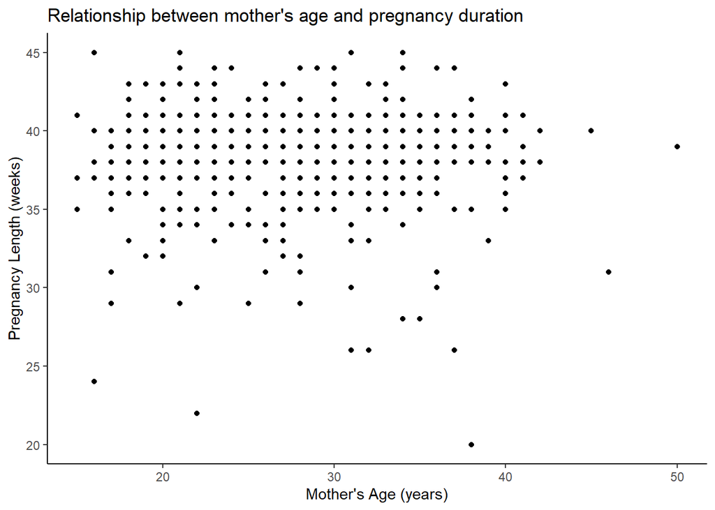

```r
ggplot(data = nc, aes(x = mage, y = weeks))+
  geom_point() +
  labs(x = "Mother's Age (years)", y = "Pregnancy Length (weeks)",
       title = "Relationship between mother's age and pregnancy duration") +
  theme_classic()
```

## Exercise 3

Study the code below, and the resulting graphical output. Note that we added a new argument of `color = premie` and `shape = marital` **inside** the `aes`thetic mapping. The variable `premie` indicates whether a birth was early (premie) or went full term and `marital` represents the marital status of the mother. Please answer with text:

**A.** What did adding the argument `alpha = 0.3` accomplish?

**Answer: It makes the data points more transparent so we can see overlapping points.**

**B.** How many **variables** are now displayed on this plot?

**Answer: 4 variables are shown**

**C.** What appears to (roughly) be the pregnancy length cutoff for classifying a newborn as a “premie”" versus a “full term”.

**Answer: anywhere between 36 and 38 seems reasonable**

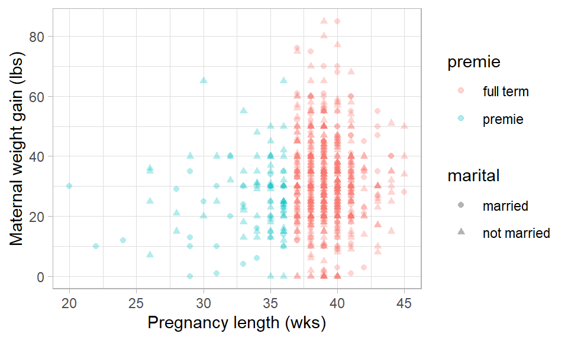

```r
ggplot(data = nc, aes(x = weeks, y = gained, color = premie, shape = marital))+
  geom_point(alpha=0.3) +
  labs(x = "Pregnancy length (wks)", y = "Maternal weight gain (lbs)") +
  theme_light()
```

## Exercise 5

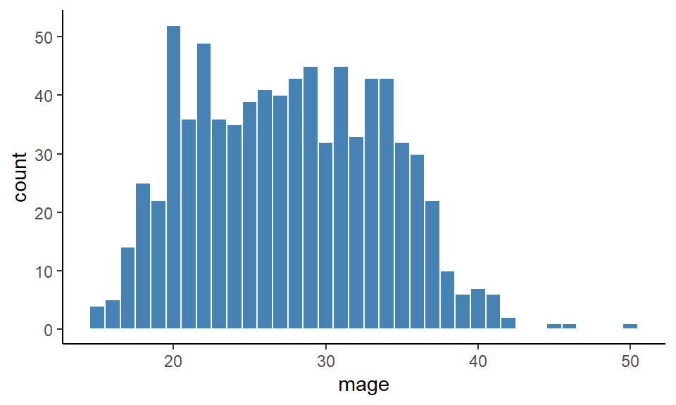

```r
ggplot(data = nc, aes(x = mage))+
  geom_histogram(binwidth = 1, color = "white", fill = "steelblue") +
  theme_classic()
```

Inspect the histogram of the `mage` variable. Answer each of the following with **text**.

**A.** The y axis is labeled **count**. What is specifically being counted in this case? Hint: think about what each case is in this data set.

**Answer: the number of mothers whose age fall into each bin specified on the histogram**

## Exercise 6

Make a histogram of the birth `weight` of newborns (which is in lbs), including a title and axis labels. (`R` code and output for answer)

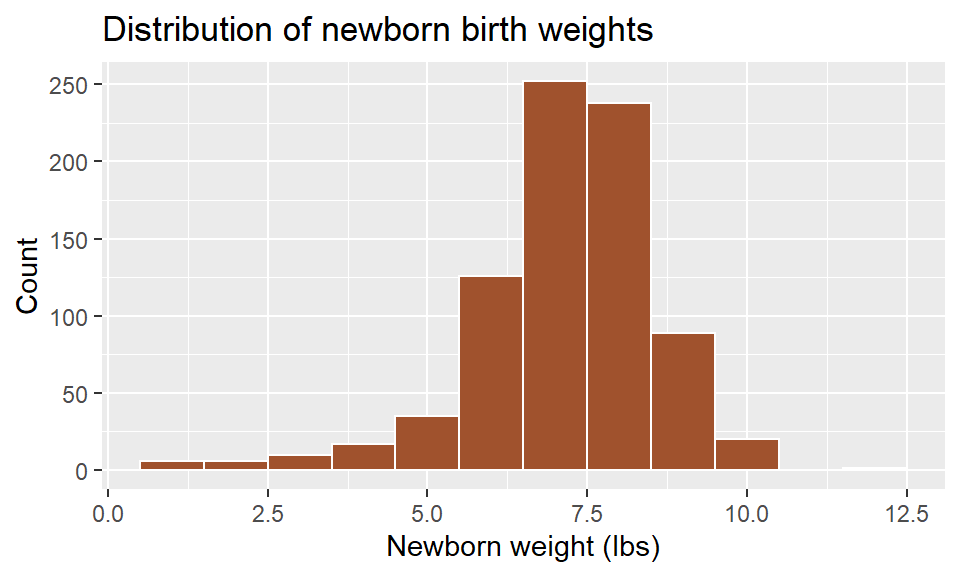

```r
ggplot(data = nc, aes(x =  weight)) +
  geom_histogram(binwidth = 1, color = "white", fill = "sienna") +
  labs(x = "Newborn weight (lbs)", y = "Count", title = "Distribution of newborn birth weights")
```

## Exercise 7

**Answer:**

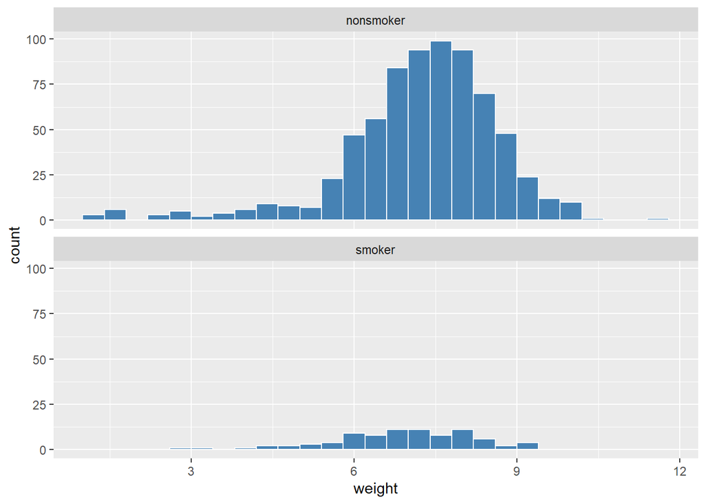

```r
ggplot(data = nc, aes(x = weight)) +
  geom_histogram(binwidth = 0.4, color = "white", fill = "steelblue") +
  facet_wrap(~ habit, ncol = 1)
```

**Answer: The babies of nonsmokers tend to have a slightly higher median birth weight**

## Exercise 8

Make a boxplot of the weight `gained` by mothers, split by the marital status of the mothers (`marital`). Include axis labels and a title on your plot. Is the variation in weight gained during pregnancy larger for married or single mothers? (Text and `R` code and output)

**Answer:**

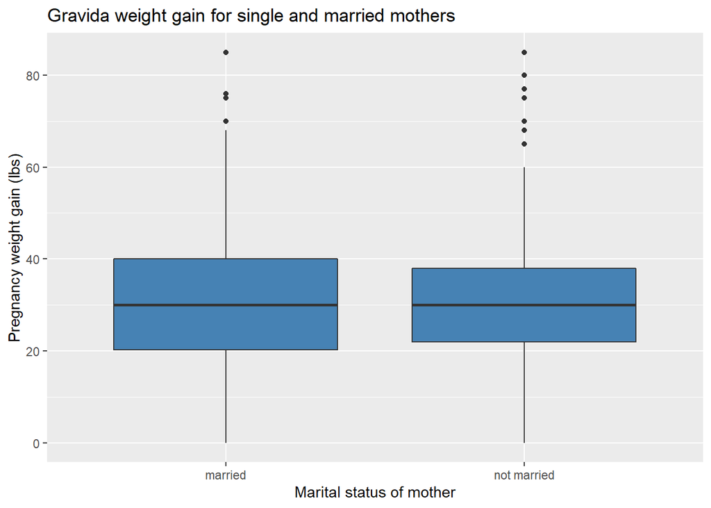

```r
ggplot(data = nc, aes(x = marital, y = gained)) +
  geom_boxplot(fill = "steelblue") +
  labs(x = "Marital status of mother", y = "Pregnancy weight gain (lbs)",
       title = "Gravida weight gain for single and married mothers")
```

**Answer: The variation is slighly greater for married mothers**

## Exercise 9

Make a boxplot of pregnancy duration in `weeks` by smoking `habit`. Are there more outliers in the duration of pregnancy for smokers or non-smokers? (Text and `R` code and output for answer)

**Answer:**

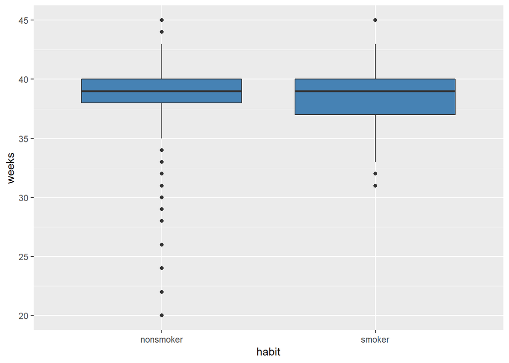

```r
ggplot(data = nc, aes(x = habit, y = weeks)) +
  geom_boxplot(fill = "steelblue")
```

**Answer: The nonsmokers have more outliers, premature babies. We are tempted to assign a cause such as the mothers are more concerned with their pregnancies and would not risk smoking. But this is only a conjecture that we have to be careful in not making.**

## Exercise 10

Make a side-by-side barplot of marital status `marital` and gender of the baby `gender`. Are female babies more common in both married and single mothers? (Text and `R` code and output for answer)

**Answer:**

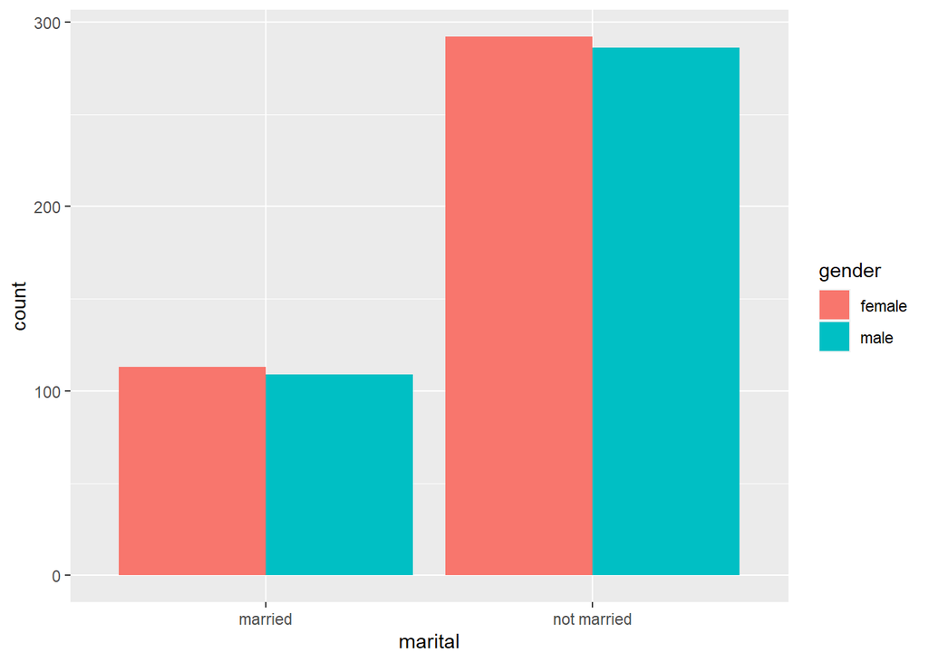

```r
ggplot(data = nc, aes(x = marital, fill = gender)) +
  geom_bar(position = "dodge")
```

**Answer: Female babies are more common in both married and single mothers.**